### Data Introduction

This data was acquired form FishBase (Froese and Pauley 2000) using the rfishbase package (Boettiger et al., 2012; see data_acquisition.R for data retrieval).

The data set includes the following variables:

- `species`: the scientific name of fish
- `genus`: the scientific genus of fish
- `common_name`: common name used for fish
- `body_shape`**: shape of fish body (elongated, fusiform/normal, eel-like, short and/or deep, other)**
- `habitat`**: area of the ocean that fish typically resides in**
- `depth_range_shallow`**: minimum depth fish is found**
- `depth_range_deep`**: maximum depth fish is found**
- `vulnerability`**: metric for how at risk a fish is to over fishing based on other life history and ecological traits**
- `length`**: total length, fork length, or standard length of fish**
- `trophic_level`**: trophic level that the fish occupies based on position in food web**
- `food_troph`: trophic level that fish’s food source occupies
- `food`**: type of food source fish consumes**
- `family`: the scientific family of fish

*Bold variables are included in the models. A full copy of the codebook is included in the data/raw folder*

#### Habitat Types

This project attempts to predict 8 different habitat types. These habitats are described below to note differences.

1. pelagic: living within several regions of the pelagic zone, through both shallower pelagic-oceanic and deeper bathypelagic
2. pelagic-neritic: relating to upper layers of the ocean on the continental shelf. Waters here are not as deep as the pelagic zone
3. reef-associated: living in association with a coral reef. This habitat is the most diverse, offering an array of food types and shelters
4. demersal: relating to living on or near the ocean floor, whether in the pelagic-neritic, pelagic, or bathypelagic zones
5. benthopelagic: relating specifically to the ocean floor in the pelagic zone, but not at the deepest depths
6. bathydemersal: relating to the ocean floor at depths greater than 200 meters
7. pelagic-oceanic: relating specifically to the upper layers of the open ocean. Food is scarce
8. bathypelagic: relating to deeper layers of the open ocean at the continental slope. Limited sunlight reaches this zone

While there is some possible overlap in these categories, they are kept separate as specifically defined in FishBase. Data has already been pre-processed for you.

#### Data Cleaning

Today, we are going to use all habitats!

```r
fish_clean = read_csv(here("discussion", "data", "fish_clean.csv")) %>%
  mutate(habitat = as.factor(habitat))
```

### Modeling

Today, we will look at preforming K-nearest neighbors on this data set. We will continue to come back to this data set as we learn more models in this section.

##### Habitat Counts

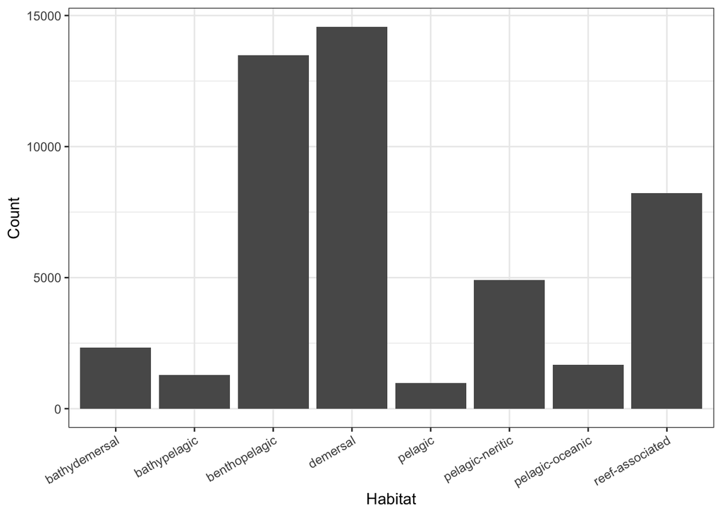

```r
ggplot(fish_clean, aes(habitat)) + #order by count
  geom_bar() + #get counts
  theme_bw() + #bw theme
  labs(x = "Habitat",
       y = "Count") + #change labels
  theme(axis.text.x = element_text(angle = 30, hjust=1)) #rotate x axis labels
```

#### Training and Testing Data Creation

Here, we will use functions from the `rsample` package within `TidyModels`

```r
data_split = initial_split(fish_clean, prop = .8, strata = habitat) #split data stratified by survived

train = training(data_split)#get training data
test = testing(data_split) #get testing data
```

```r
cv_fold = vfold_cv(train, v = 5)
```

#### Recipe Creation

After splitting my data, the first step is to create a recipe indicating the formula for the model and any pre-processing steps I want to preform on my data. Here we will use the `recipes` package.

I will be predicting habitat based on trophic level, length, minimum depth, maximum depth, vulnerability, body shape, and food source type. We will be normalizing all numeric predictors

```r
# create model recipe
fish_recipe <- recipe(habitat ~ shape_impute + food_impute + shallow_impute + deep_impute + vulnerability + length_impute + trophic_level_impute, data = train) %>%
  # create dummy variables from all factors
  step_dummy(all_nominal_predictors()) %>%
  step_normalize(all_numeric_predictors())
```

#### Model 3: K-nearest neighbors

```r
?nearest_neighbor
```

I will be using the kknn engine (Schliep and Hechenbichler 2016) for this model and tuning the number of neighbors (k) to determine the best value.

```r
knn_model <- nearest_neighbor(neighbors = tune()) %>%
  set_mode("classification") %>%
  set_engine("kknn")

knn_model
```

```
## K-Nearest Neighbor Model Specification (classification)
##
## Main Arguments:
##   neighbors = tune()
##
## Computational engine: kknn
```

```r
knn_workflow <- workflow() %>%
  add_model(knn_model) %>%
  add_recipe(fish_recipe) # will automatically prep and bake when adding to workflow

knn_workflow
```

```
## ══ Workflow ════════════════════════════════════════════════════════════════════
## Preprocessor: Recipe
## Model: nearest_neighbor()
##
## ── Preprocessor ────────────────────────────────────────────────────────────────
## 2 Recipe Steps
##
## • step_dummy()
## • step_normalize()
##
## ── Model ───────────────────────────────────────────────────────────────────────
## K-Nearest Neighbor Model Specification (classification)
##
## Main Arguments:
##   neighbors = tune()
##
## Computational engine: kknn
```

##### Parameter Tuning

```r
# Would take awhile to load so we will use .rda file to do this step
knn_cv_tune <- knn_workflow %>%
  tune_grid(resamples = cv_folds, grid = 5) # use cross validation to nearest neighbors
```

```r
collect_metrics(knn_cv_tune)
```

```
## # A tibble: 10 × 7
##    neighbors .metric  .estimator  mean     n std_err .config
##        <int> <chr>    <chr>      <dbl> <int>   <dbl> <chr>
##  1         3 accuracy multiclass 0.791     5 0.00277 Preprocessor1_Model1
##  2         3 roc_auc  hand_till  0.905     5 0.00133 Preprocessor1_Model1
##  3         5 accuracy multiclass 0.786     5 0.00342 Preprocessor1_Model2
##  4         5 roc_auc  hand_till  0.920     5 0.00172 Preprocessor1_Model2
##  5         9 accuracy multiclass 0.785     5 0.00271 Preprocessor1_Model3
##  6         9 roc_auc  hand_till  0.931     5 0.00246 Preprocessor1_Model3
##  7        11 accuracy multiclass 0.779     5 0.00352 Preprocessor1_Model4
##  8        11 roc_auc  hand_till  0.934     5 0.00225 Preprocessor1_Model4
##  9        15 accuracy multiclass 0.771     5 0.00371 Preprocessor1_Model5
## 10        15 roc_auc  hand_till  0.937     5 0.00179 Preprocessor1_Model5
```

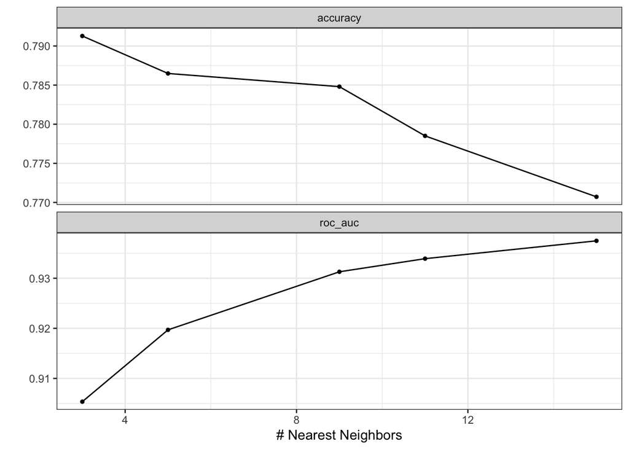

```r
# plot cv results for parameter tuning
autoplot(knn_cv_tune) +
  theme_bw()
```

#### Finalize workflow

```r
?show_best
?finalize_workflow()
```

```r
show_best(knn_cv_tune, metric = "roc_auc")
```

```
## # A tibble: 5 × 7
##   neighbors .metric .estimator  mean     n std_err .config
##       <int> <chr>   <chr>      <dbl> <int>   <dbl> <chr>
## 1        15 roc_auc hand_till  0.937     5 0.00179 Preprocessor1_Model5
## 2        11 roc_auc hand_till  0.934     5 0.00225 Preprocessor1_Model4
## 3         9 roc_auc hand_till  0.931     5 0.00246 Preprocessor1_Model3
## 4         5 roc_auc hand_till  0.920     5 0.00172 Preprocessor1_Model2
## 5         3 roc_auc hand_till  0.905     5 0.00133 Preprocessor1_Model1
```

```r
knn_final <- finalize_workflow(knn_workflow, select_best(knn_cv_tune, metric = "roc_auc"))
knn_final
```

```
## ══ Workflow ════════════════════════════════════════════════════════════════════
## Preprocessor: Recipe
## Model: nearest_neighbor()
##
## ── Preprocessor ────────────────────────────────────────────────────────────────
## 2 Recipe Steps
##
## • step_dummy()
## • step_normalize()
##
## ── Model ───────────────────────────────────────────────────────────────────────
## K-Nearest Neighbor Model Specification (classification)
##
## Main Arguments:
##   neighbors = 15
##
## Computational engine: kknn
```

#### Model Fitting

*these all take a few seconds*

```r
library(kknn)
```

```r
train_fit <- fit(knn_final, train) #fit the KNN model to the training set

train_fit
```

```
## ══ Workflow [trained] ══════════════════════════════════════════════════════════
## Preprocessor: Recipe
## Model: nearest_neighbor()
##
## ── Preprocessor ────────────────────────────────────────────────────────────────
## 2 Recipe Steps
##
## • step_dummy()
## • step_normalize()
##
## ── Model ───────────────────────────────────────────────────────────────────────
##
## Call:
## kknn::train.kknn(formula = ..y ~ ., data = data, ks = min_rows(15L,     data, 5))
##
## Type of response variable: nominal
## Minimal misclassification: 0.2166702
## Best kernel: optimal
## Best k: 15
```

```r
train_predict <- predict(object = train_fit, new_data = train) %>% #predict the training set
  bind_cols(train) #bind training set column to prediction

train_predict2 <- predict(object = train_fit, new_data = train, type = "prob") %>% #predict the training set
  bind_cols(train) #bind training set column to prediction
```

```r
test_predict <- predict(train_fit, test) %>% #get prediction probabilities for test
  bind_cols(test) %>%  #bind to testing column
  mutate(habitat = as.factor(habitat))

test_predict2 <- predict(train_fit, test, type = "prob") %>% #get testing prediction
  bind_cols(test) %>%  #bind to testing column
  mutate(habitat = as.factor(habitat))
```

#### Model Metrics and Evaluation

```r
accuracy(train_predict, truth = habitat, estimate = .pred_class) #get training accuracy
```

```
## # A tibble: 1 × 3
##   .metric  .estimator .estimate
##   <chr>    <chr>          <dbl>
## 1 accuracy multiclass     0.861
```

```r
sensitivity(train_predict, truth = habitat, estimate = .pred_class)
```

```
## # A tibble: 1 × 3
##   .metric     .estimator .estimate
##   <chr>       <chr>          <dbl>
## 1 sensitivity macro          0.826
```

```r
specificity(train_predict, truth = habitat, estimate = .pred_class)
```

```
## # A tibble: 1 × 3
##   .metric     .estimator .estimate
##   <chr>       <chr>          <dbl>
## 1 specificity macro          0.977
```

```r
test_roc_auc <- roc_curve(train_predict2, habitat,
                         .pred_bathydemersal, .pred_bathypelagic, .pred_benthopelagic,
                         .pred_demersal, .pred_demersal, .pred_pelagic,
                         '.pred_pelagic-neritic', '.pred_pelagic-oceanic', '.pred_reef-associated')

test_roc_auc
```

```
## # A tibble: 24,412 × 4
##    .level        .threshold specificity sensitivity
##    <chr>              <dbl>       <dbl>       <dbl>
##  1 bathydemersal -Inf             0               1
##  2 bathydemersal    0             0               1
##  3 bathydemersal    0.00259       0.926           1
##  4 bathydemersal    0.00259       0.927           1
##  5 bathydemersal    0.00798       0.929           1
##  6 bathydemersal    0.00798       0.930           1
##  7 bathydemersal    0.0106        0.930           1
##  8 bathydemersal    0.0106        0.932           1
##  9 bathydemersal    0.0137        0.932           1
## 10 bathydemersal    0.0137        0.933           1
## # ℹ 24,402 more rows
```

```r
test_predict <- predict(train_fit, test) %>% #get prediction probabilities for test
  bind_cols(test) %>%  #bind to testing column
  mutate(habitat = as.factor(habitat))

test_predict2 <- predict(train_fit, test, type = "prob") %>% #get testing prediction
  bind_cols(test) %>%  #bind to testing column
  mutate(habitat = as.factor(habitat))
```

```r
accuracy(test_predict, truth = habitat, estimate = .pred_class) #get accuracy of testing prediction
```

```
## # A tibble: 1 × 3
##   .metric  .estimator .estimate
##   <chr>    <chr>          <dbl>
## 1 accuracy multiclass     0.787
```

```r
sensitivity(test_predict, truth = habitat, estimate = .pred_class)
```

```
## # A tibble: 1 × 3
##   .metric     .estimator .estimate
##   <chr>       <chr>          <dbl>
## 1 sensitivity macro          0.760
```

```r
specificity(test_predict, truth = habitat, estimate = .pred_class)
```

```
## # A tibble: 1 × 3
##   .metric     .estimator .estimate
##   <chr>       <chr>          <dbl>
## 1 specificity macro          0.965
```

```r
#get testing ROC AUC
```

[output not shown]

#### Visualizations

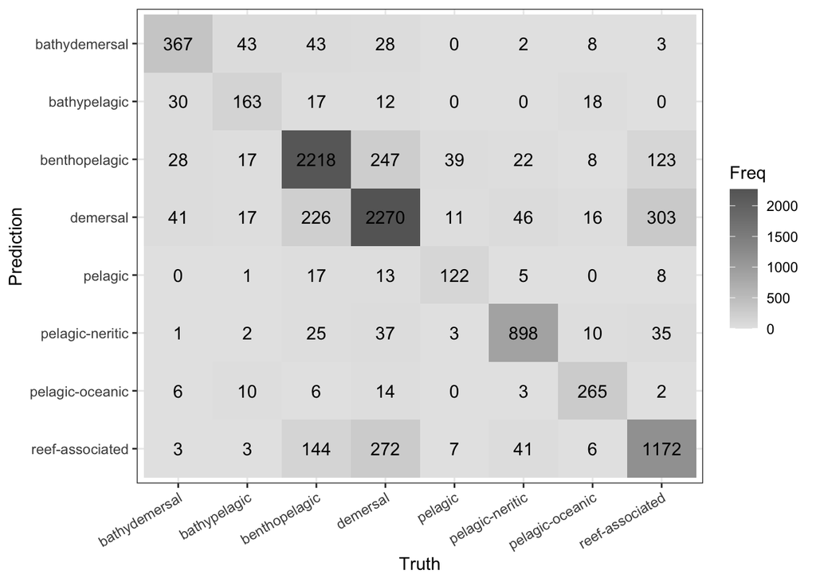

```r
test_predict %>%
  conf_mat(truth = habitat, estimate = .pred_class) %>%
  autoplot(type = "heatmap") +
  theme_bw() +
  theme(axis.text.x = element_text(angle = 30, hjust = 1))
```